# Collecting Newspaper Data in R

## NYT Article Search API: Visualizations

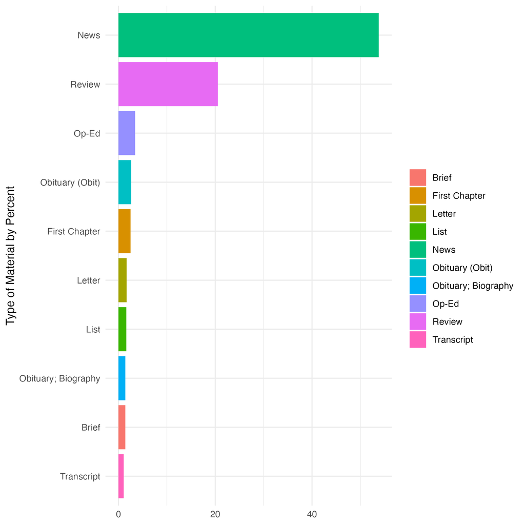

```r
# Visualize coverage by section
p2 <- nobel_articles %>%
  group_by(response.docs.type_of_material) %>%
  summarize(count=n()) %>%
  mutate(percent = (count / sum(count))*100) %>%
  arrange(desc(percent)) %>%
  filter(!is.na(response.docs.type_of_material)) %>%
  top_n(10, percent) %>%
  ggplot(aes(x=reorder(response.docs.type_of_material, percent), y=percent, fill = response.docs.type_of_material)) +
  geom_bar(stat = "identity") +
  labs(x = "Type of Material by Percent", y = NULL) +
  guides(fill=guide_legend(title=NULL)) +
  theme_minimal() +
  coord_flip()

p2
```

Years with the most coverage.

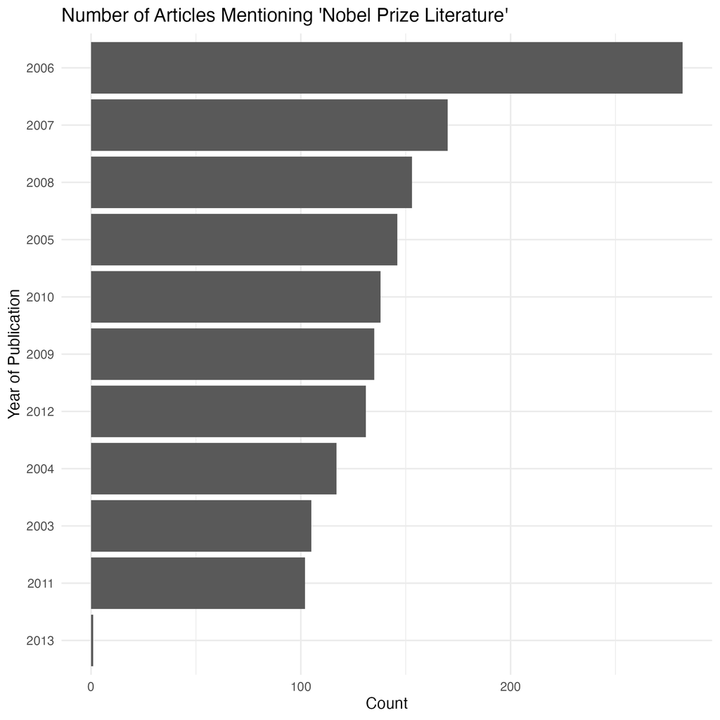

Coverage by year

```r
p3 <- nobel_articles %>%
  mutate(pubDay = gsub("T.*","",response.docs.pub_date),
         pubYear = lubridate::year(pubDay)) %>%
  group_by(pubYear) %>%
  summarise(count=n()) %>%
  ggplot(aes(x=reorder(pubYear, count), y=count)) +
  geom_bar(stat="identity") +
  labs(x = "Year of Publication", y = "Count", title = "Number of Articles Mentioning 'Nobel Prize Literature'") +
  theme_minimal() +
  coord_flip()

p3
```

So, what went on in 2006? There are several factors, but two obvious contributors were the revelation of Gûnther Grass’s controversial past as well Turkish writer Orhan Pamuk’s award that year, which came as something of a surprise.

```r
# reformat the pub_date as a date object in R, then pass a filter for 2006
nobel_articles %>%
  mutate(pub_date = lubridate::ymd_hms(response.docs.pub_date, tz="UTC")) %>%
  filter(pub_date > "2005-12-31 00:00:00" &
         pub_date < "2007-01-01 00:00:00") %>%
  select(response.docs.headline.main, response.docs.word_count) %>% #select headline and word count
  arrange(desc(response.docs.word_count)) %>% # descending sort by word count
  View() # open table view
```

## Exercise: NYT Article Search API

Develop your own query for Article Search. Use Boehmer’s slides, which are excellent, as a reminder of the possibilities and syntax: http://jamesboehmer.github.io/nytd2013/#/6.

```r
# read your NYT api key back into memory, if needed
# load("nytimes_apikey")

your_nyt <- request("https://api.nytimes.com/svc/search/v2") %>%
  req_url_path_append("/articlesearch.json") %>%
  req_url_query(`api-key` = nyt_apikey,
                q = "YOUR KEYWORDS") %>%
  req_perform()

your_nyt <- your_nyt %>% resp_body_string()

your_nyt_flat <- fromJSON(your_nyt, flatten = TRUE) %>% data.frame()
```

## Write to file

Want to use a spreadsheet application to manipulate or filter your data instead of R? Use the `write_csv()` function from the readr package to write your newspaper data to a comma separated value file (.csv). This is a file format that can be read in any spreadsheet application, like Excel or Google sheets. The file will appear in your Files panel in the lower right. Select it with your cursor, then go to More (gear icon) > Export and save to your computer.

```r
# save your cats or nobel_articles datasets using this line
# need help with any of the write functions? enter ?write_csv() at the console

readr::write_csv(cats_df, "cats-loc-dataset.csv")
```

## Sources

Boehmer, James. “The New York Times Article Search API.” 2013. http://jamesboehmer.github.io/nytd2013/.

Evans, Daniel. “Chronicling America’s Newspaper Biographies as Data.” The National Endowment for the Humanities (blog), February 16, 2023. https://www.neh.gov/blog/chronicling-americas-newspaper-biographies-data.

Fitzgerald, Jonathan D. “Working with The New York Times API in R.” 2018. https://www.storybench.org/working-with-the-new-york-times-api-in-r/.

Freeman, Michael, and Joel Ross. “Accessing Web APIs.” In *Technical Foundations of Informatics*. Seattle, WA: UW Information School, 2019. https://info201.github.io/.

LC Labs. “Library of Congress Data Exploration.” Last updated May 17, 2023. https://github.com/LibraryOfCongress/data-exploration

## Projects that Use Newspaper Data

Interested in exploring projects in the humanities that use newspaper data? You might be interested in the winners of the [Chronicling America Data Challenge](https://www.neh.gov/news/press-release/2016-07-25). I’d also recommend searching [*Reviews in Digital Humanities*](https://reviewsindh.pubpub.org/) for any mention of “newspaper.”

Lastly, Martin Saveedra (thanks, Martin!) tipped me off to the work of Melissa Dell on the Chronicling America data that improves OCR and detects content areas. I haven’t dipped into it yet, but I thought I’d pass along the information. “American Stories”: https://dell-research-harvard.github.io/resources/americanstories.

[^1]: For more information about the Rutgers side of things, visit the [New Jersey Digital Newspaper Project website](https://njdnp.libraries.rutgers.edu/).
[^2]: Information on the Chronicling America APIs and bulk downloads is available at https://www.loc.gov/collections/chronicling-america/about-this-collection/technical-information/.
[^3]: For more on rate limits with the Chronicling America API, see https://libraryofcongress.github.io/data-exploration/loc.gov%20JSON%20API/Chronicling_America/README.html#rate-limits-and-definitions.